# exploration

To get started let's import all the libraries

```python
import numpy as mp
import pandas as pd
import matplotlib.pyplot as plt
import seaborn as sns
%matplotlib inline
```

**Load both Seattle and Boston listings data**

```python
df_seattle = pd.read_csv('seattle/listings.csv')
df_boston = pd.read_csv('boston-airbnb-open-data/listings.csv')
```

## Data Exploration

```python
#load sample Seattle data
df_seattle.head()
```

|  | id | listing_url | scrape_id | last_scraped | name | summary | space | description | experiences_offered | neighborhood_overview | ... | review_scores_value | requires_license | license | jurisdiction_names | instant_bookable | cancellation_policy | require_guest_profile_picture | require_guest_phone_verification | calculated_host_listings_count | reviews_per_month |
| --- | --- | --- | --- | --- | --- | --- | --- | --- | --- | --- | --- | --- | --- | --- | --- | --- | --- | --- | --- | --- | --- |
| 0 | 241032 | https://www.airbnb.com/rooms/241032 | 20160104002432 | 2016-01-04 | Stylish Queen Anne Apartment | NaN | Make your self at home in this charming one-be... | Make your self at home in this charming one-be... | none | NaN | ... | 10.0 | f | NaN | WASHINGTON | f | moderate | f | f | 2 | 4.07 |
| 1 | 953595 | https://www.airbnb.com/rooms/953595 | 20160104002432 | 2016-01-04 | Bright & Airy Queen Anne Apartment | Chemically sensitive? We've removed the irrita... | Beautiful, hypoallergenic apartment in an extr... | Chemically sensitive? We've removed the irrita... | none | Queen Anne is a wonderful, truly functional vi... | ... | 10.0 | f | NaN | WASHINGTON | f | strict | t | t | 6 | 1.48 |
| 2 | 3308979 | https://www.airbnb.com/rooms/3308979 | 20160104002432 | 2016-01-04 | New Modern House-Amazing water view | New modern house built in 2013. Spectacular s... | Our house is modern, light and fresh with a wa... | New modern house built in 2013. Spectacular s... | none | Upper Queen Anne is a charming neighborhood fu... | ... | 10.0 | f | NaN | WASHINGTON | f | strict | f | f | 2 | 1.15 |
| 3 | 7421966 | https://www.airbnb.com/rooms/7421966 | 20160104002432 | 2016-01-04 | Queen Anne Chateau | A charming apartment that sits atop Queen Anne... | NaN | A charming apartment that sits atop Queen Anne... | none | NaN | ... | NaN | f | NaN | WASHINGTON | f | flexible | f | f | 1 | NaN |
| 4 | 278830 | https://www.airbnb.com/rooms/278830 | 20160104002432 | 2016-01-04 | Charming craftsman 3 bdm house | Cozy family craftman house in beautiful neighb... | Cozy family craftman house in beautiful neighb... | Cozy family craftman house in beautiful neighb... | none | We are in the beautiful neighborhood of Queen ... | ... | 9.0 | f | NaN | WASHINGTON | f | strict | f | f | 1 | 0.89 |

5 rows × 92 columns

```python
df_seattle.shape
```

```
(3818, 92)
```

```python
df_seattle.describe()
```

|  | id | scrape_id | host_id | host_listings_count | host_total_listings_count | latitude | longitude | accommodates | bathrooms | bedrooms | ... | review_scores_rating | review_scores_accuracy | review_scores_cleanliness | review_scores_checkin | review_scores_communication | review_scores_location | review_scores_value | license | calculated_host_listings_count | reviews_per_month |
| --- | --- | --- | --- | --- | --- | --- | --- | --- | --- | --- | --- | --- | --- | --- | --- | --- | --- | --- | --- | --- | --- |
| count | 3.818000e+03 | 3.818000e+03 | 3.818000e+03 | 3816.000000 | 3816.000000 | 3818.000000 | 3818.000000 | 3818.000000 | 3802.000000 | 3812.000000 | ... | 3171.000000 | 3160.000000 | 3165.000000 | 3160.000000 | 3167.000000 | 3163.000000 | 3162.000000 | 0.0 | 3818.000000 | 3191.000000 |
| mean | 5.550111e+06 | 2.016010e+13 | 1.578556e+07 | 7.157757 | 7.157757 | 47.628961 | -122.333103 | 3.349398 | 1.259469 | 1.307712 | ... | 94.539262 | 9.636392 | 9.556398 | 9.786709 | 9.809599 | 9.608916 | 9.452245 | NaN | 2.946307 | 2.078919 |
| std | 2.962660e+06 | 0.000000e+00 | 1.458382e+07 | 28.628149 | 28.628149 | 0.043052 | 0.031745 | 1.977599 | 0.590369 | 0.883395 | ... | 6.606083 | 0.698031 | 0.797274 | 0.595499 | 0.568211 | 0.629053 | 0.750259 | NaN | 5.893029 | 1.822348 |
| min | 3.335000e+03 | 2.016010e+13 | 4.193000e+03 | 1.000000 | 1.000000 | 47.505088 | -122.417219 | 1.000000 | 0.000000 | 0.000000 | ... | 20.000000 | 2.000000 | 3.000000 | 2.000000 | 2.000000 | 4.000000 | 2.000000 | NaN | 1.000000 | 0.020000 |
| 25% | 3.258256e+06 | 2.016010e+13 | 3.275204e+06 | 1.000000 | 1.000000 | 47.609418 | -122.354320 | 2.000000 | 1.000000 | 1.000000 | ... | 93.000000 | 9.000000 | 9.000000 | 10.000000 | 10.000000 | 9.000000 | 9.000000 | NaN | 1.000000 | 0.695000 |
| 50% | 6.118244e+06 | 2.016010e+13 | 1.055814e+07 | 1.000000 | 1.000000 | 47.623601 | -122.328874 | 3.000000 | 1.000000 | 1.000000 | ... | 96.000000 | 10.000000 | 10.000000 | 10.000000 | 10.000000 | 10.000000 | 10.000000 | NaN | 1.000000 | 1.540000 |
| 75% | 8.035127e+06 | 2.016010e+13 | 2.590309e+07 | 3.000000 | 3.000000 | 47.662694 | -122.310800 | 4.000000 | 1.000000 | 2.000000 | ... | 99.000000 | 10.000000 | 10.000000 | 10.000000 | 10.000000 | 10.000000 | 10.000000 | NaN | 2.000000 | 3.000000 |
| max | 1.034016e+07 | 2.016010e+13 | 5.320861e+07 | 502.000000 | 502.000000 | 47.733358 | -122.240607 | 16.000000 | 8.000000 | 7.000000 | ... | 100.000000 | 10.000000 | 10.000000 | 10.000000 | 10.000000 | 10.000000 | 10.000000 | NaN | 37.000000 | 12.150000 |

8 rows × 30 columns

```python
df_seattle.columns
```

```
Index(['id', 'listing_url', 'scrape_id', 'last_scraped', 'name', 'summary',
       'space', 'description', 'experiences_offered', 'neighborhood_overview',
       'notes', 'transit', 'thumbnail_url', 'medium_url', 'picture_url',
       'xl_picture_url', 'host_id', 'host_url', 'host_name', 'host_since',
       'host_location', 'host_about', 'host_response_time',
       'host_response_rate', 'host_acceptance_rate', 'host_is_superhost',
       'host_thumbnail_url', 'host_picture_url', 'host_neighbourhood',
       'host_listings_count', 'host_total_listings_count',
       'host_verifications', 'host_has_profile_pic', 'host_identity_verified',
       'street', 'neighbourhood', 'neighbourhood_cleansed',
       'neighbourhood_group_cleansed', 'city', 'state', 'zipcode', 'market',
       'smart_location', 'country_code', 'country', 'latitude', 'longitude',
       'is_location_exact', 'property_type', 'room_type', 'accommodates',
       'bathrooms', 'bedrooms', 'beds', 'bed_type', 'amenities', 'square_feet',
       'price', 'weekly_price', 'monthly_price', 'security_deposit',
       'cleaning_fee', 'guests_included', 'extra_people', 'minimum_nights',
       'maximum_nights', 'calendar_updated', 'has_availability',
       'availability_30', 'availability_60', 'availability_90',
       'availability_365', 'calendar_last_scraped', 'number_of_reviews',
       'first_review', 'last_review', 'review_scores_rating',
       'review_scores_accuracy', 'review_scores_cleanliness',
       'review_scores_checkin', 'review_scores_communication',
       'review_scores_location', 'review_scores_value', 'requires_license',
       'license', 'jurisdiction_names', 'instant_bookable',
       'cancellation_policy', 'require_guest_profile_picture',
       'require_guest_phone_verification', 'calculated_host_listings_count',
       'reviews_per_month'],
      dtype='object')
```

Looks like it has a lot of columns and many of which are not needed like the **listing _url**. Let's reduce the df columns to those which we think are relevant.

```python
#drop unwanted columns
unwanted_columns = ['id', 'listing_url', 'scrape_id', 'last_scraped', 'name', 'space', 'description', \
                    'experiences_offered', 'neighborhood_overview', \
                    'notes', 'transit', 'thumbnail_url', 'medium_url', 'picture_url',
       'xl_picture_url', 'host_id', 'host_url', 'host_name','host_location', 'host_about', 'host_thumbnail_url', \
                    'host_picture_url', 'host_neighbourhood', 'host_has_profile_pic', 'host_identity_verified', \
                    'street', 'city', 'state', 'zipcode', 'market',
       'smart_location', 'country_code', 'country', 'latitude', 'longitude', 'weekly_price', 'monthly_price',\
                    'calendar_updated', 'has_availability', 'host_total_listings_count',
       'availability_30', 'availability_60', 'availability_90', 'host_verifications',
       'availability_365', 'calendar_last_scraped', 'calendar_updated', 'has_availability',
       'availability_30', 'availability_60', 'availability_90',
       'availability_365', 'calendar_last_scraped', 'first_review', 'last_review',
       'review_scores_accuracy', 'review_scores_cleanliness',
       'review_scores_checkin', 'review_scores_communication',
       'review_scores_location', 'review_scores_value', 'license', 'jurisdiction_names', 'require_guest_profile_picture',
       'require_guest_phone_verification', 'calculated_host_listings_count']
```

```python
#remove unwanted columns from our dataset
def drop_unwanted_columns_df(df):
    df = df.drop(labels = unwanted_columns, axis =1)
    return df
```

## Question 1:

**Does price have an impact on the review scores?** Let's check both the fields and see if we have to do any data wrangling.

```python
#remove '$', and ',' values
def clean_price(df):
    df['price']=df['price'].apply(lambda x: x.strip("$|,"))
    df['price']=df['price'].apply(lambda x: x.replace(',',""))
    #convert price from string to numeric values
    df['price'] = pd.to_numeric(df['price'])
    df.dropna(subset=['price'], inplace=True)
    return df
```

```python
def clean_review_ratings(df):
    df.dropna(subset=['review_scores_rating'], inplace=True)
    return df
```

**Now that we have our functions ready, let's build our first chart to compare price vs ratings on Seattle data.**

```python
df_seattle = drop_unwanted_columns_df(df_seattle)
df_seattle = clean_price(df_seattle)
df_seattle = clean_review_ratings(df_seattle)

df_seattle.shape
```

```
(3171, 33)
```

```python
df_seattle.columns
```

[output not shown]

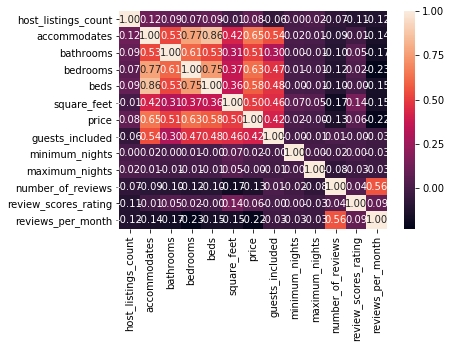

```python
#see correlation in data for Seattle
sns.heatmap(df_seattle.corr(), annot=True, fmt='.2f');
```

We see high correlation between Accommodates, Bathrooms, Bedrooms, beds, square_feet, guests_included and price. This is in expected lines.

```python
df_seattle[['price','review_scores_rating']].describe()
```

|  | price | review_scores_rating |
| --- | --- | --- |
| count | 3171.000000 | 3171.000000 |
| mean | 126.802586 | 94.539262 |
| std | 90.007172 | 6.606083 |
| min | 22.000000 | 20.000000 |
| 25% | 75.000000 | 93.000000 |
| 50% | 100.000000 | 96.000000 |
| 75% | 150.000000 | 99.000000 |
| max | 1000.000000 | 100.000000 |

**Repeating the steps for Boston data**

```python
df_boston = drop_unwanted_columns_df(df_boston)
df_boston = clean_price(df_boston)
df_boston = clean_review_ratings(df_boston)

df_boston.head()
```

|  | summary | access | interaction | house_rules | host_since | host_response_time | host_response_rate | host_acceptance_rate | host_is_superhost | host_listings_count | ... | guests_included | extra_people | minimum_nights | maximum_nights | number_of_reviews | review_scores_rating | requires_license | instant_bookable | cancellation_policy | reviews_per_month |
| --- | --- | --- | --- | --- | --- | --- | --- | --- | --- | --- | --- | --- | --- | --- | --- | --- | --- | --- | --- | --- | --- |
| 1 | Charming and quiet room in a second floor 1910... | Apt has one more bedroom (which I use) and lar... | If I am at home, I am likely working in my hom... | Pet friendly but please confirm with me if the... | 2012-06-07 | within an hour | 100% | 100% | f | 1 | ... | 0 | $0.00 | 2 | 15 | 36 | 94.0 | f | t | moderate | 1.30 |
| 2 | Come stay with a friendly, middle-aged guy in ... | I am living in the apartment during your stay,... | ABOUT ME: I'm a laid-back, friendly, unmarried... | I encourage you to use my kitchen, cooking and... | 2009-05-11 | within a few hours | 100% | 88% | t | 1 | ... | 1 | $20.00 | 3 | 45 | 41 | 98.0 | f | f | moderate | 0.47 |
| 3 | Come experience the comforts of home away from... | The basement has a washer dryer and gym area. ... | We do live in the house therefore might be som... | - The bathroom and house are shared so please ... | 2013-04-21 | within a few hours | 100% | 50% | f | 1 | ... | 2 | $25.00 | 1 | 1125 | 1 | 100.0 | f | f | moderate | 1.00 |
| 4 | My comfy, clean and relaxing home is one block... | You will have access to the front and side por... | I love my city and really enjoy sharing it wit... | Please no smoking in the house, porch or on th... | 2014-05-11 | within an hour | 100% | 100% | t | 1 | ... | 1 | $0.00 | 2 | 31 | 29 | 99.0 | f | f | flexible | 2.25 |
| 5 | Super comfy bedroom plus your own bathroom in ... | Guests are welcome to share our living room an... | We're busy but always happy to have guests in ... | No smoking, please, and no drugs. | 2016-03-23 | within a few hours | 100% | 95% | t | 2 | ... | 1 | $0.00 | 2 | 1125 | 8 | 100.0 | f | f | flexible | 1.70 |

5 rows × 36 columns

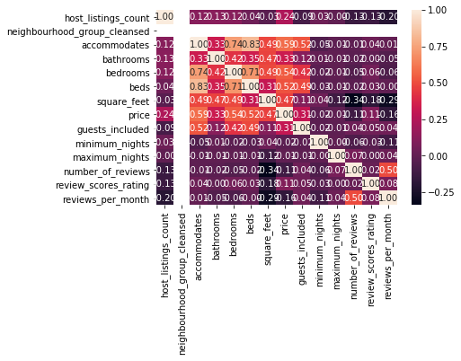

```python
#see correlation in data for Boston
sns.heatmap(df_boston.corr(), annot=True, fmt='.2f');
```

We see high correlation between Accommodates, Bathrooms, Bedrooms, beds, square_feet, guests_included and price. This is also in expected lines.

### Price vs Review Ratings: Scatter Plots for Seattle & Boston

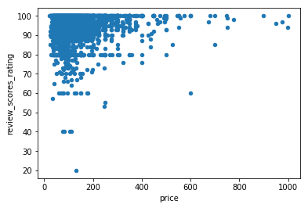

```python
#scatter plot for price vs Review Ratings for Seattle
df_seattle.plot.scatter('price','review_scores_rating');
```

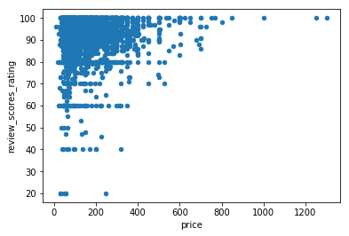

```python
#scatter plot for price vs Review Ratings for Boston
df_boston.plot.scatter('price','review_scores_rating');
```

```python
df_boston[['price','review_scores_rating']].describe()
```

|  | price | review_scores_rating |
| --- | --- | --- |
| count | 2772.000000 | 2772.000000 |
| mean | 166.684343 | 91.916667 |
| std | 112.972898 | 9.531686 |
| min | 11.000000 | 20.000000 |
| 25% | 85.000000 | 89.000000 |
| 50% | 145.000000 | 94.000000 |
| 75% | 215.000000 | 98.250000 |
| max | 1300.000000 | 100.000000 |

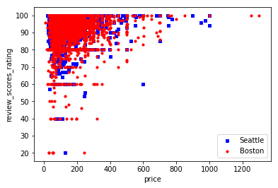

```python
#combine scatter plots of Seattle and Boston
plt.scatter(df_seattle['price'], df_seattle['review_scores_rating'], s=10, c='b', marker="s", label='Seattle')
plt.scatter(df_boston['price'], df_boston['review_scores_rating'], s=10, c='r', marker="o", label='Boston')
plt.legend(loc='lower right');
plt.xlabel('price')
plt.ylabel('review_scores_rating')
plt.show()
```

It is clear from the above graph that there is no difference in the dynamics of pricing vs reviews in Seattle and Bosotn. They follow a similar pattern in both the cities. The pattern however by itself is interesting. As the price goes up, the number of overall ratings come down which is as expected as the total number of people staying will also come down. And the average rating goes up as the price goes up, which again can be attributed to better services, and facilities being available at higher price points.

## Question 2:

**How do Seattle and Boston homeowners describe their houses? Is there a difference in the way top reviewed houses are described?**

```python
#clean Summary column in both datasets
df_seattle.dropna(subset=['summary'], inplace=True)
df_boston.dropna(subset=['summary'], inplace=True)
```

```python
#build word cloud function

#import necessary libraries that are specific for this question
from PIL import Image
from wordcloud import WordCloud, STOPWORDS, ImageColorGenerator

def build_word_cloud(df_column):
    #add obvious words we do not want to see in the word cloud to our stop words list
    stop_words = ["seattle", "Boston","room"] + list(STOPWORDS)

    wordcloud = WordCloud(stopwords=stop_words).generate(' '.join(df_column))
    #display the generated image
    plt.imshow(wordcloud, interpolation='bilinear')
    plt.axis("off")
    plt.show()
```

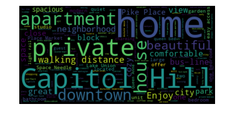

```python
#Seattle listing summary word cloud:
build_word_cloud(df_seattle['summary'])
```

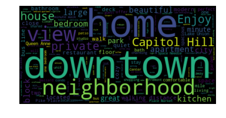

```python
#Seattle word cloud for top 25%ile listings
build_word_cloud(df_seattle.summary[df_seattle.review_scores_rating>99])
```

**Seattle Word Cloud discussion**

- At an aggregate level for overall listings within Seattle, the summaries seem to have the following words at a higher frequency: beautiful, comfortable, private home, being near downtown, things being available at walking distance. Capitol Hill area also seems to be very popular.
- When you compare it against the top 25 percentile homes in Seattle (75th percentile for review ratings in Seattle is 99), majority of the words are similar. However, there are few interesting words which had higher frequency amongst those with high ratings. These are neighborhood, kitchen, large, and downtown.

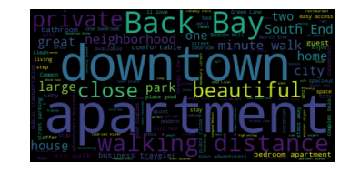

```python
#Boston Listing summary word cloud:
build_word_cloud(df_boston['summary'])
```

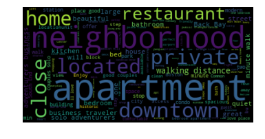

```python
#Boston word cloud for top 25%ile listings
build_word_cloud(df_boston.summary[df_boston.review_scores_rating>99])
```

**Boston Word Cloud discussion**

- At an aggregate level for overall listings within Boston, the summaries seem to have the following words at a higher frequency: downtown, Back bay location, beautiful, park, South end, private home, and park.
- When you compare it against the top 25 percentile homes in Boston (75th percentile for review ratings in Boston is 98), majority of the words are similar. However, there are few interesting words which had higher frequency amongst those with high ratings. These are neighbourhood, located, being near restaurant, and close. Being close to happening places, seem to be the major driver behind getting higher ratings in Boston as per the word cloud.

```python
#save cleaned Seattle and Boston files
df_seattle.to_csv('Seattle_cleaned.csv')
df_boston.to_csv('Boston_cleaned.csv')
```

```python
#load cleaned Seattle and Boston CSVs
df_seattle = pd.read_csv('Seattle_cleaned.csv')
df_boston = pd.read_csv('Boston_cleaned.csv')
```

## Question 3:

**What are the best neighbourhoods to stay in Seattle and Boston?**

```python
def get_best_neighbourhoods(df, min_listings, top_x):

    #input:
    # df = dataframe for which you need the best neighbourhoods
    # min_listings = minimum number of listings needed in neighbourhoods
    # top_x = show top x results in output
    #output:
    # best neighbourhoods along with their average rating score and the number of listings in those neighbourhoods

    #Get mean review ratings by neighbourhood
    df_q3a = df.groupby('neighbourhood_cleansed', as_index=False)['review_scores_rating'].mean().\
    sort_values('review_scores_rating', ascending=False)

    #Get count of listings by neighbourhood
    df_q3b=df.neighbourhood_cleansed.value_counts().rename_axis('neighbourhood_cleansed').reset_index(name='counts')

    # Merge both averages of review ratings and number of listings into one table
    df_q3 = pd.merge(df_q3a, df_q3b, on='neighbourhood_cleansed')

    #get neighbourhoods ratings, and number of listings available
    return df_q3[df_q3['counts']>=min_listings].head(top_x)
```

```python
#Top 10 neighbourhoods in Seattle with at least 10 listings
df_seattle_q3 = get_best_neighbourhoods(df_seattle,10,10)
df_seattle_q3
```

|  | neighbourhood_cleansed | review_scores_rating | counts |
| --- | --- | --- | --- |
| 1 | Madrona | 97.538462 | 39 |
| 3 | Southeast Magnolia | 97.214286 | 14 |
| 4 | Harrison/Denny-Blaine | 97.200000 | 10 |
| 5 | Genesee | 96.933333 | 30 |
| 6 | North Beach/Blue Ridge | 96.909091 | 11 |
| 8 | North Delridge | 96.666667 | 24 |
| 9 | Whittier Heights | 96.571429 | 21 |
| 10 | North College Park | 96.428571 | 14 |
| 11 | Minor | 96.270492 | 122 |
| 12 | Broadview | 96.266667 | 15 |

```python
#Top 10 neighbourhoods in Boston with at least 10 listings
df_boston_q3 = get_best_neighbourhoods(df_boston,10,10)
df_boston_q3
```

|  | neighbourhood_cleansed | review_scores_rating | counts |
| --- | --- | --- | --- |
| 1 | Roslindale | 95.489362 | 47 |
| 2 | West Roxbury | 95.156250 | 32 |
| 3 | South Boston Waterfront | 94.431034 | 58 |
| 4 | Jamaica Plain | 94.266667 | 285 |
| 5 | South Boston | 94.026490 | 151 |
| 7 | Charlestown | 93.731343 | 67 |
| 8 | North End | 93.687500 | 112 |
| 9 | South End | 93.478261 | 253 |
| 10 | Beacon Hill | 93.427711 | 166 |
| 11 | Bay Village | 93.000000 | 16 |

```python
#create plot function
def build_plot_best_beighbourhoods(df):
    fig, ax = plt.subplots(figsize= (20,8))
    ax1 = ax.twinx()
    sns.barplot(ax=ax, x=df['neighbourhood_cleansed'], y=df['counts']);
    sns.lineplot(ax=ax1,x=df['neighbourhood_cleansed'], y=df['review_scores_rating']);
```

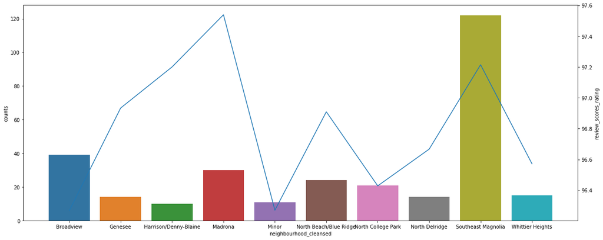

```python
#Seattle best neighbourhoods plot
build_plot_best_beighbourhoods(df_seattle_q3)
```

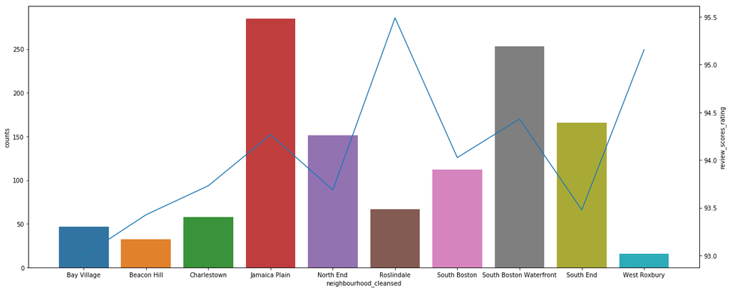

```python
#Boston best neighbourhoods plot
build_plot_best_beighbourhoods(df_boston_q3)
```